# Grasping_Task_Analysis

## Fails by condition

```r
# Bar plot: x = fail, exfail (grouped by condition), y = counts
combined_data %>% group_by(condition, success) %>% count() %>% filter(success != "success")
```

```
## # A tibble: 4 × 3
## # Groups:   condition, success [4]
##   condition success     n
##   <fct>     <fct>   <int>
## 1 auditory  exFail     11
## 2 auditory  fail        5
## 3 tactile   exFail     18
## 4 tactile   fail       64
```

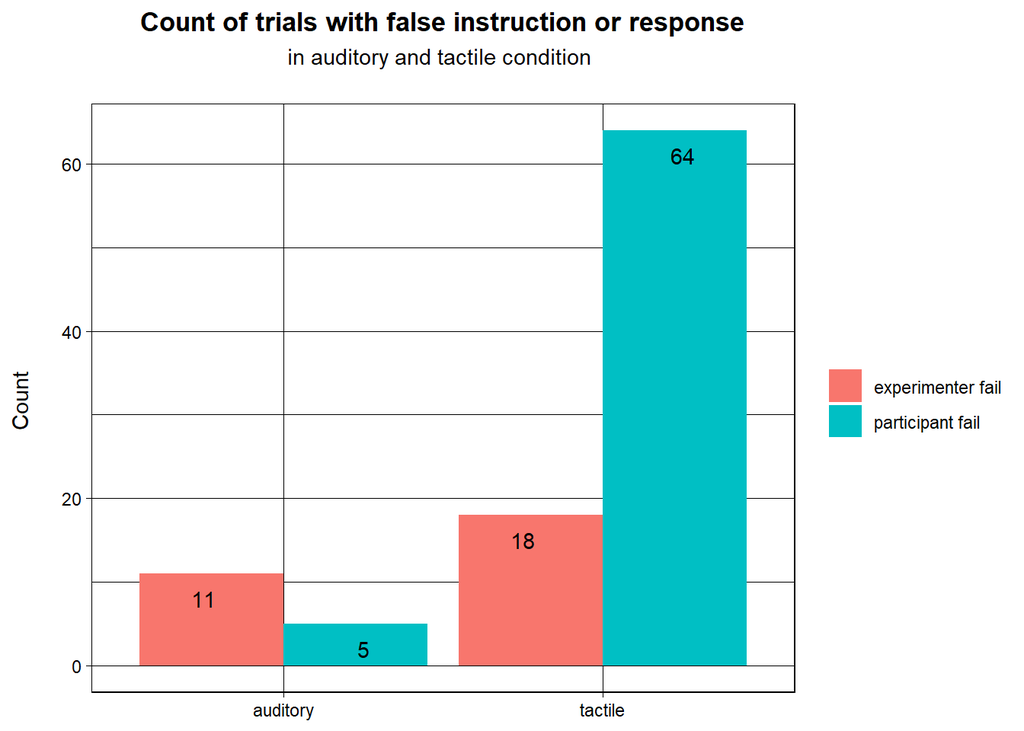

```r
Grasping_countOfFailTrials <- combined_data %>% group_by(condition, success) %>% count() %>% filter(success != "success") %>%
  ggplot(aes(x = condition, y = n, fill = success)) +
  geom_bar(stat = "identity", position = "dodge") +
  geom_text(aes(label = n), position = position_dodge(width = 1), vjust = 2, hjust=0.5) +
  scale_y_continuous(breaks = scales::pretty_breaks()) +
  labs(
    title = "Count of trials with false instruction or response",
    x = NULL,
    y = "Count \n",
    subtitle = "in auditory and tactile condition \n"
    ) +
  theme_linedraw() +
  theme(plot.title = element_text(face = "bold", hjust = 0.5),
    plot.subtitle = element_text(hjust = 0.5),
    legend.position = "right", legend.title = element_blank()) +
  scale_fill_discrete(labels = c("experimenter fail", "participant fail"))

Grasping_countOfFailTrials
```

```r
ggsave("Grasping_countOfFailTrials.pdf", plot = Grasping_countOfFailTrials, dpi = 600)
```

```r
# Line plot: x = block (grouped by condition --> 2 lines), y = fail counts
combined_data %>% group_by(block, condition) %>% summarize(fail_count = sum(success == "fail"), exFail_count = sum(success == "exFail"))
```

```
## # A tibble: 6 × 4
## # Groups:   block [3]
##   block condition fail_count exFail_count
##   <dbl> <fct>          <int>        <int>
## 1     1 auditory           0            3
## 2     1 tactile           30           10
## 3     2 auditory           2            1
## 4     2 tactile           20            3
## 5     3 auditory           3            7
## 6     3 tactile           14            5
```

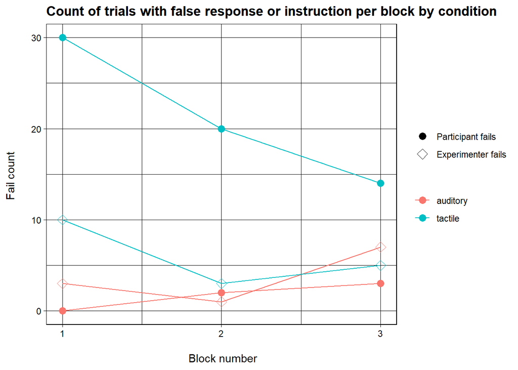

```r
fails_per_block <- combined_data %>% group_by(block, condition) %>% summarize(fail_count = sum(success == "fail"), exFail_count = sum(success == "exFail")) %>%
  ggplot(aes(x = block, y = fail_count, color=condition)) +
  geom_point(aes(y = fail_count, shape="Group 1"), size=3) +
  geom_line(aes(y = fail_count)) +
  geom_point(aes(y = exFail_count, shape="Group 2"), size=3) +
  geom_line(aes(y = exFail_count)) +
  labs(
    title = "Count of trials with false response or instruction per block by condition",
    x = "\n Block number",
    y = "Fail count \n"
    ) +
  theme_linedraw() +
  theme(plot.title = element_text(face = "bold"), legend.position = "right", legend.title = element_blank()) +
  scale_x_continuous(breaks = c(1:8)) +
  scale_shape_manual(
    name = "Fail type",
    values = c("Group 1" = 16, "Group 2" = 5),  # Use 16 for a solid point
    labels = c("Participant fails", "Experimenter fails"))

fails_per_block
```

```r
ggsave("fails_per_block_blind.pdf", plot = fails_per_block, dpi = 600)

# test for significance
fails_a <- combined_data %>% group_by(block, condition) %>% summarize(fail_count = sum(success == "fail")) %>% filter(condition=="auditory")
fails_t <- combined_data %>% group_by(block, condition) %>% summarize(fail_count = sum(success == "fail")) %>% filter(condition=="tactile")

t.test(fails_a$fail_count, fails_t$fail_count)
```

```
##
##  Welch Two Sample t-test
##
## data:  fails_a$fail_count and fails_t$fail_count
## t = -4.141, df = 2.1427, p-value = 0.04763
## alternative hypothesis: true difference in means is not equal to 0
## 95 percent confidence interval:
##  -38.8510147  -0.4823186
## sample estimates:
## mean of x mean of y
##  1.666667 21.333333
```

```r
fails_time <- combined_data %>% group_by(block, condition) %>% summarize(fail_count = sum(success == "fail"), mean_time = mean(time)) %>% filter(condition=="tactile")
cor.test(fails_time$mean_time, fails_time$fail_count)
```

```
##
##  Pearson's product-moment correlation
##
## data:  fails_time$mean_time and fails_time$fail_count
## t = 7.3736, df = 1, p-value = 0.08581
## alternative hypothesis: true correlation is not equal to 0
## sample estimates:
##       cor
## 0.9909287
```

# Linear Mixed-Effects Model (LMM)

## Data preparation

```r
grasping_data <- combined_data %>% filter(success == "success") %>% select(-success)

# rename repetition locations in df
grasping_data$location[grasping_data$location == "rep_1"] = "1"
grasping_data$location[grasping_data$location == "rep_2"] = "2"
grasping_data$location[grasping_data$location == "rep_3"] = "3"
grasping_data$location[grasping_data$location == "rep_4"] = "4"
grasping_data$location[grasping_data$location == "rep_5"] = "5"
grasping_data$location[grasping_data$location == "rep_6"] = "6"
grasping_data$location[grasping_data$location == "rep_7"] = "7"
grasping_data$location[grasping_data$location == "rep_8"] = "8"
grasping_data$location[grasping_data$location == "rep_9"] = "9"
grasping_data$time <- grasping_data$time*1000 # s -> ms

# cast block number and number of instructions to characters
grasping_data$block <- as.character(grasping_data$block) # numeric to character for linear mixed model
grasping_data$num_instructions <- as.character(grasping_data$num_instructions)
```

## Model comparison & selection

In order to decide which variables are included in the LMM and which are excluded, we evaluate models, compare them, test for significant effects and investigate their complexity in terms of number of coefficients/parameters.

**Decision train of thought:** - variables: num_instructions, location, block, condition, pID  
- fixed effects we are interested in: condition (difference between sensory modalities), block (learning effects)  
- In the first comparision, we decided to add ‘location’ as fixed effect. The model with location is significant and according to test results, it gives a little more exact information (not only instructions = 2, but also whether top-left, top-right or bottom-left, bottom-right) but makes the model drastically more complex –> In the end, because the effect can be due to the experimental settings, location is not our initial interest, and the model with location is very complex, we have decided to exclude location.

- We’ve decided to add ‘participant_id’ as random effects to see how individual participants differ from one another and how these differences relate to the variables of interest.
- In the second comparision, we try to understand how we should approach the variability across participants in the relationship between the condition variable and time. Model_complex1 allows for this variability by including random slopes for condition, and this means that the effect of condition on time is allowed to vary across different participants. However, Model_complex3 assumes a constant effect of condition across participants, accounting for variability only through random intercepts. -the likelihood ratio test results indicate a significant difference in fit between the two models, with model_complex1 providing a better fit compared to model_complex3. This suggests that including random slopes for condition within each participant_id improves the model’s ability to capture the variability in the data. So, we’ve decided use model_complex1 as our final model.
- (model comparison: anova with the likelihood ratio test (The chi-square test))

**Resources:** - LMM Tutorial: https://www.youtube.com/watch?v=QCqF-2E86r0 !!!  
- Interpretation explanation: https://www.youtube.com/watch?v=yJnHmCMb1q4  
- An LMM example (interaction explanation): https://www.youtube.com/watch?v=W8txfclM16U

```r
# model testing: decide which variables to include/exclude (with lmerTest)

#First comparison
model_complex1 <- lmer(time ~ condition * block * (condition |participant_id ), data = grasping_data)

model_complex2 <- lmer(time ~ condition * block * location * (condition |participant_id ), data = grasping_data)


model_comparison1 <- anova(model_complex1, model_complex2, test = "Chisq")
model_comparison1
```

```
## Data: grasping_data
## Models:
## model_complex1: time ~ condition * block * (condition | participant_id)
## model_complex2: time ~ condition * block * location * (condition | participant_id)
##                npar   AIC   BIC logLik deviance Chisq Df Pr(>Chisq)
## model_complex1   10 33025 33081 -16503    33005
## model_complex2   52 32373 32662 -16135    32269 735.8 42  < 2.2e-16 ***
## ---
## Signif. codes:  0 '***' 0.001 '**' 0.01 '*' 0.05 '.' 0.1 ' ' 1
```

```r
summary(model_complex1)
```

```
## Linear mixed model fit by REML. t-tests use Satterthwaite's method [
## lmerModLmerTest]
## Formula: time ~ condition * block * (condition | participant_id)
##    Data: grasping_data
##
## REML criterion at convergence: 32936.1
##
## Scaled residuals:
##     Min      1Q  Median      3Q     Max
## -3.7099 -0.5587 -0.0787  0.4064  8.7203
##
## Random effects:
##  Groups         Name             Variance Std.Dev. Corr
##  participant_id (Intercept)      1693437  1301
##                 conditiontactile 1500320  1225     -0.17
##  Residual                        1818501  1349
## Number of obs: 1899, groups:  participant_id, 41
##
## Fixed effects:
##                         Estimate Std. Error       df t value Pr(>|t|)
## (Intercept)             4551.587    216.443   47.132  21.029  < 2e-16 ***
## conditiontactile         682.612    219.370   56.459   3.112  0.00292 **
## block2                  -501.611    105.469 1813.000  -4.756 2.13e-06 ***
## block3                  -558.282    105.560 1813.059  -5.289 1.38e-07 ***
## conditiontactile:block2   -5.069    152.038 1813.824  -0.033  0.97341
## conditiontactile:block3 -134.836    151.780 1813.595  -0.888  0.37446
## ---
## Signif. codes:  0 '***' 0.001 '**' 0.01 '*' 0.05 '.' 0.1 ' ' 1
##
## Correlation of Fixed Effects:
##             (Intr) cndtnt block2 block3 cndt:2
## conditntctl -0.256
## block2      -0.243  0.240
## block3      -0.243  0.239  0.498
## cndtntctl:2  0.168 -0.346 -0.694 -0.345
## cndtntctl:3  0.169 -0.346 -0.346 -0.695  0.500
```

```r
summary(model_complex2)
```

```
## Linear mixed model fit by REML. t-tests use Satterthwaite's method [
## lmerModLmerTest]
## Formula: time ~ condition * block * location * (condition | participant_id)
##    Data: grasping_data
##
## REML criterion at convergence: 31677.8
##
## Scaled residuals:
##     Min      1Q  Median      3Q     Max
## -3.7438 -0.4553 -0.0859  0.2825  9.1771
##
## Random effects:
##  Groups         Name             Variance Std.Dev. Corr
##  participant_id (Intercept)      1714839  1310
##                 conditiontactile 1604827  1267     -0.18
##  Residual                        1240800  1114
## Number of obs: 1899, groups:  participant_id, 41
##
## Fixed effects:
##                                    Estimate Std. Error        df t value
## (Intercept)                        5320.376    268.493   110.821  19.816
## conditiontactile                   1288.946    317.072   221.408   4.065
## block2                             -685.612    246.022  1770.970  -2.787
## block3                             -565.621    247.618  1771.068  -2.284
## location2                         -1295.426    246.022  1770.970  -5.265
## location3                          -145.170    246.022  1770.970  -0.590
## location4                         -1520.154    246.022  1770.970  -6.179
## location6                         -1718.438    246.022  1770.970  -6.985
## location7                           109.602    246.022  1770.970   0.445
## location8                         -1571.646    246.022  1770.970  -6.388
## location9                            -9.080    246.022  1770.970  -0.037
## conditiontactile:block2            -583.525    353.943  1771.185  -1.649
## conditiontactile:block3            -726.714    356.531  1771.346  -2.038
## conditiontactile:location2         -542.856    355.315  1771.223  -1.528
## conditiontactile:location3           79.834    356.779  1771.285   0.224
## conditiontactile:location4        -1051.056    354.045  1771.254  -2.969
## conditiontactile:location6         -418.893    350.396  1771.194  -1.195
## conditiontactile:location7         -941.537    354.155  1771.329  -2.659
## conditiontactile:location8         -923.467    352.859  1771.312  -2.617
## conditiontactile:location9        -1047.624    347.149  1771.109  -3.018
```

[output cut: 64 more lines]

```
## conditiontactile:block3:location2  0.11288
## conditiontactile:block2:location3  0.77834
## conditiontactile:block3:location3  0.40915
## conditiontactile:block2:location4  0.10793
## conditiontactile:block3:location4  0.05923 .
## conditiontactile:block2:location6  0.67330
## conditiontactile:block3:location6  0.54859
## conditiontactile:block2:location7  0.08351 .
## conditiontactile:block3:location7  0.00856 **
## conditiontactile:block2:location8  0.21706
## conditiontactile:block3:location8  0.31650
## conditiontactile:block2:location9  0.14842
## conditiontactile:block3:location9  0.21027
## ---
## Signif. codes:  0 '***' 0.001 '**' 0.01 '*' 0.05 '.' 0.1 ' ' 1
```